# Data Scientist - Analytical Exercise Part2- PaySafe

TimLin

10/18/2016

Data Sources: https://www.lendingclub.com/info/download-data.action  
Download 2015 Loan Data from the “Download Loan Data” section and load the data from csv file into R data frame, and check the dimension of the data:

```r
library(plyr)
library(ggplot2)
```

```r
setwd("~/data")
data<-read.csv("LoanStats3d.csv",header=TRUE,sep=",")
dim(data)
```

```
## [1] 421095    111
```

##### Set B1 (answer at least one question)

##### 1. LC uses a number of variables to determine the pricing for its loans. Review and attempt to explain the relationship between the

1. sub_grade
2. the int_rate
3. the loan_amnt, and d) the loan term (variable= term).

First, I will plot the pair scatter-plot between four variables to inspect the relation:

```r
datab1<- data[,c("sub_grade","int_rate","loan_amnt","term")]
str(datab1)
```

```
## 'data.frame':    421095 obs. of  4 variables:
##  $ sub_grade: Factor w/ 35 levels "A1","A2","A3",..: 8 1 15 8 6 8 18 11 5 11 ...
##  $ int_rate : Factor w/ 110 levels "10.49%","10.64%",..: 109 86 28 109 104 109 40 10 100 10 ...
##  $ loan_amnt: int  14000 25000 16000 15000 15000 24000 2500 28800 10000 35000 ...
##  $ term     : Factor w/ 2 levels " 36 months"," 60 months": 1 1 2 1 1 2 1 2 1 2 ...
```

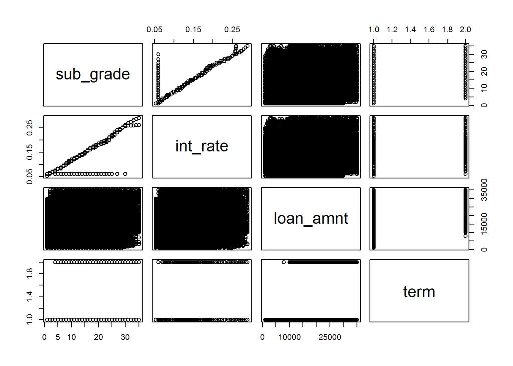

```r
#transfer the factor to percentage numeric type
datab1$int_rate<-levels(datab1$int_rate)[datab1$int_rate]
datab1$int_rate<-as.numeric(sub("%","",datab1$int_rate))/100

pairs(datab1)
```

It seems that there are some linear relations betweens “sub_grade” and “the int_rate”. It also seems there are some patterns between “loan_ammounts”" and “sub_grade”.

Let us make a closer inspection between each pair of variables:

1. Relation between “int_rate incease” and “sub_grades”:

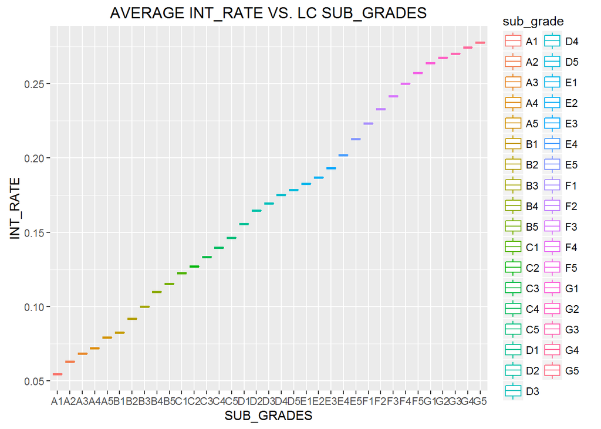

```r
# plot the mean of int_rate for each sub_grade
te<-data.frame(sub_grade=levels(datab1$sub_grade),int_rate_mean=with(datab1, tapply(int_rate, sub_grade, mean)), loan_amnt_mean=with(datab1, tapply(loan_amnt, sub_grade, mean)))

qplot(sub_grade, int_rate_mean, data = te, geom = "boxplot", color = sub_grade) +
  xlab(toupper("SUB_GRADES")) +
  ylab("INT_RATE") +
  ggtitle("AVERAGE INT_RATE VS. LC SUB_GRADES")
```

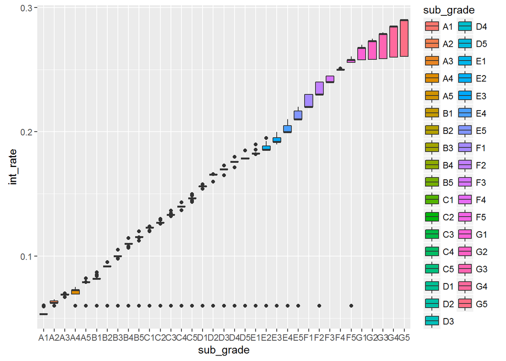

```r
ggplot(datab1,aes(x=sub_grade,y=int_rate,fill=sub_grade))+geom_boxplot()
```

```r
#Using One-Way ANOVA to test the significant relation between int_rate(continous) and sub_grade(categorical)
summary(aov(int_rate~sub_grade, datab1))
```

```
##                 Df Sum Sq Mean Sq F value Pr(>F)
## sub_grade       34  783.3   23.04 4811728 <2e-16 ***
## Residuals   421060    2.0    0.00
## ---
## Signif. codes:  0 '***' 0.001 '**' 0.01 '*' 0.05 '.' 0.1 ' ' 1
```

From the plots, we can see that the mean and the variance of “int_rate” incease from “sub_grades” is A1 to G5.  
From the Anova, we can see that p-value is very small which implies that the correlation between variables is significant.

2. Relation between “loan_amnt” and “sub_grades”:

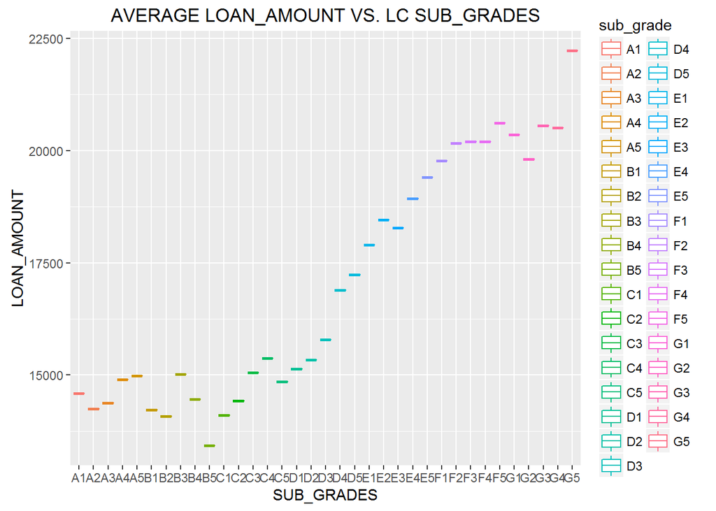

```r
# plot the mean of loan_amnt for each sub_grade

qplot(sub_grade, loan_amnt_mean, data = te, geom = "boxplot", color = sub_grade) +
  xlab(toupper("SUB_GRADES")) +
  ylab("LOAN_AMOUNT") +
  ggtitle("AVERAGE LOAN_AMOUNT VS. LC SUB_GRADES")
```

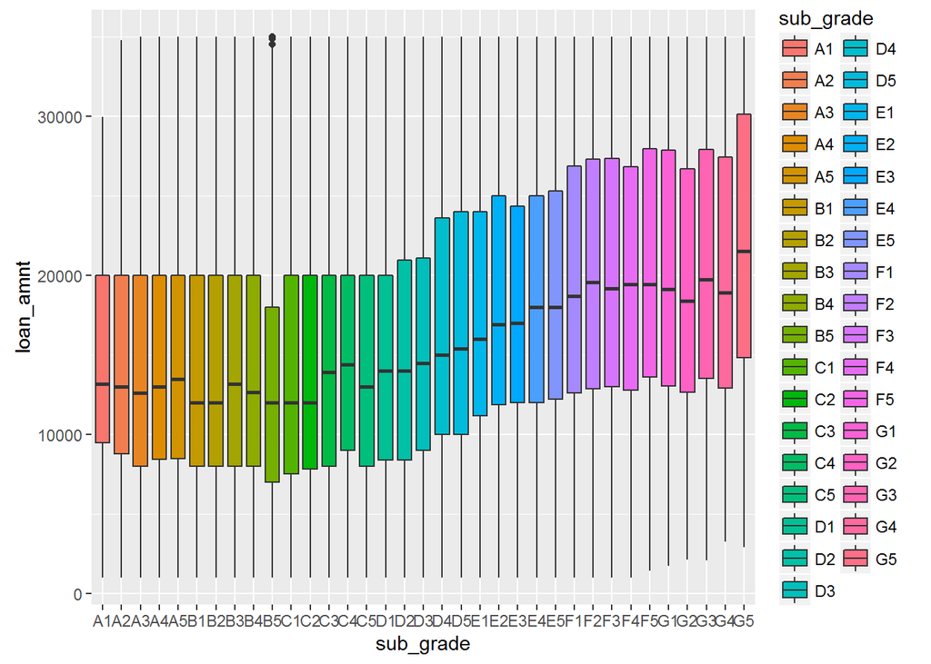

```r
ggplot(datab1,aes(x=sub_grade,y=loan_amnt,fill=sub_grade))+geom_boxplot()
```

```r
#Using One-Way ANOVA to test the significant relation between int_rate(continous) and sub_grade(categorical)
summary(aov(loan_amnt~sub_grade, datab1))
```

```
##                 Df    Sum Sq   Mean Sq F value Pr(>F)
## sub_grade       34 9.691e+11 2.850e+10   400.5 <2e-16 ***
## Residuals   421060 2.997e+13 7.117e+07
## ---
## Signif. codes:  0 '***' 0.001 '**' 0.01 '*' 0.05 '.' 0.1 ' ' 1
```

From the plots, we can see that the mean and the variance of “loan_amnt”" incease from “sub_grades”" is A1 to G5.  
From the Anova, we can see that the p-value is very small, which implies the correlation between variables is significant.

3. Relation between “term” and “sub_grades”:

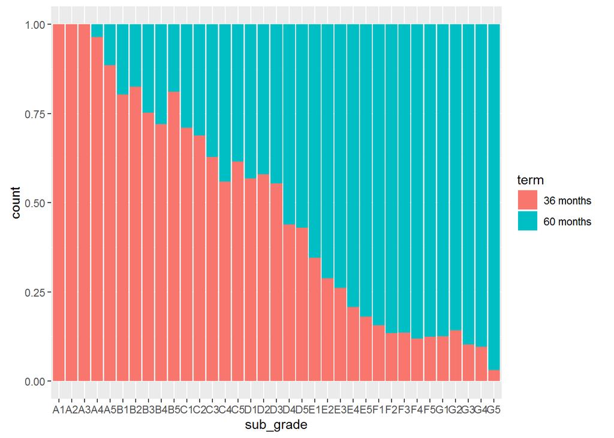

```r
ggplot(datab1,aes(x=sub_grade))+ geom_bar(aes(fill = term, stat = "identity"), position = "fill")
```

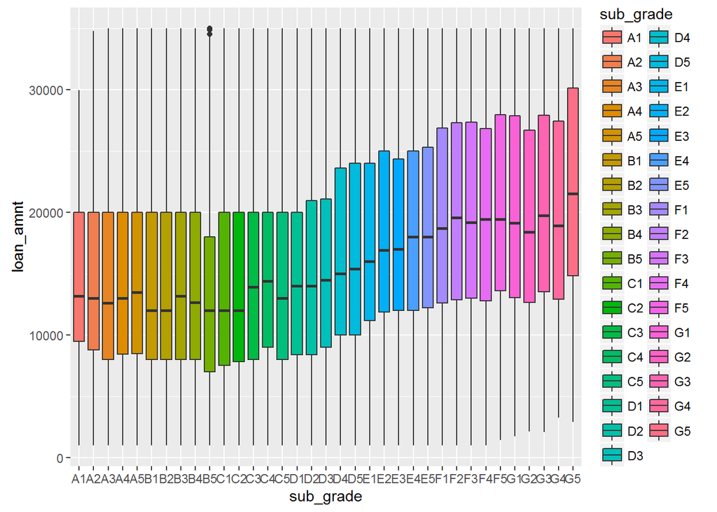

```r
ggplot(datab1,aes(x=sub_grade,y=loan_amnt,fill=sub_grade))+geom_boxplot()
```

```r
#Using Chi-square test and Cramer V to test the significant relationship between term(categorical) and sub_grade(categorical)
tb = table(datab1$sub_grade,datab1$term)
chisq.test(tb)
```

```
##
##  Pearson's Chi-squared test
##
## data:  tb
## X-squared = 86391, df = 34, p-value < 2.2e-16
```

```r
cv.test = function(x,y) {
  CV = sqrt(chisq.test(x, y, correct=FALSE)$statistic /
    (length(x) * (min(length(unique(x)),length(unique(y))) - 1)))
  print.noquote("Cramér V / Phi:")
  return(as.numeric(CV))
}
cv.test(datab1$sub_grade,datab1$term)
```

```
## [1] Cramer V / Phi:
```

```
## [1] 0.4529448
```

From the plots, we can see that the percentage of observation of 60 months term has increased from “sub_grades” A1 to G5.  
From the Chi-square test, we can see that the p-value is very small, which implies that the correlation between variables is significant, and that Cramer V / Phi shows a normal strength of correlation.

4. Relation between “loan_amnt” and “int_rate”:

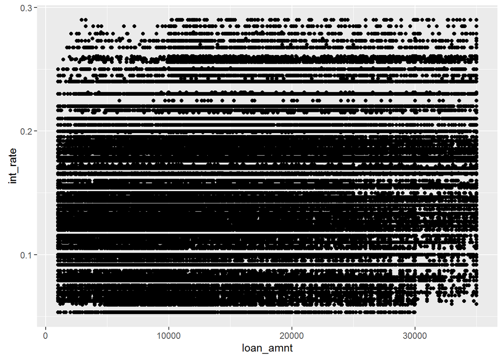

```r
# Plot the boxplot of int_rate within different terms
ggplot(datab1,aes(x=loan_amnt,y=int_rate))+geom_point()
```

```r
# Inspect Pearson correlation between variabes
cor.test(datab1$loan_amnt,datab1$int_rate)
```

```
##
##  Pearson's product-moment correlation
##
## data:  datab1$loan_amnt and datab1$int_rate
## t = 92.151, df = 421090, p-value < 2.2e-16
## alternative hypothesis: true correlation is not equal to 0
## 95 percent confidence interval:
##  0.1376355 0.1435568
## sample estimates:
##       cor
## 0.1405974
```

The output shows that there is a significant correlation between “loan_amnt” and “int_rate” which is 0.14.

5. Relation between “term” and “int_rate”:

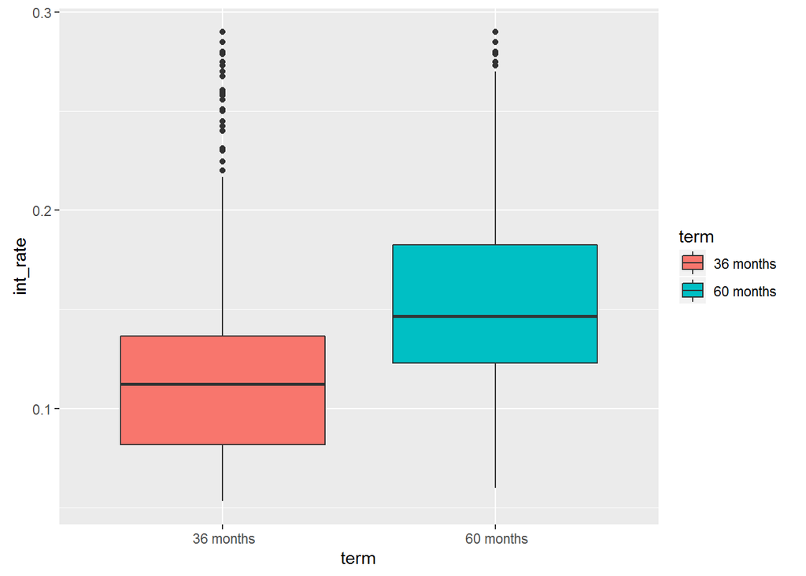

```r
ggplot(datab1,aes(x=term,y=int_rate,fill=term))+geom_boxplot()
```

```r
#Using One-Way ANOVA to test the significant relation between int_rate(continous) and term(categorical)
summary(aov(int_rate~term, datab1))
```

```
##                 Df Sum Sq Mean Sq F value Pr(>F)
## term             1  151.2   151.2  100419 <2e-16 ***
## Residuals   421093  634.1     0.0
## ---
## Signif. codes:  0 '***' 0.001 '**' 0.01 '*' 0.05 '.' 0.1 ' ' 1
```

The plot shows that the distribution of “int_rate” of 36-months “term” seems lower than 60-months and a low p-value from the ANOVA test shows a significant relationship.

6. Relation between “term” and “loan_amnt”:

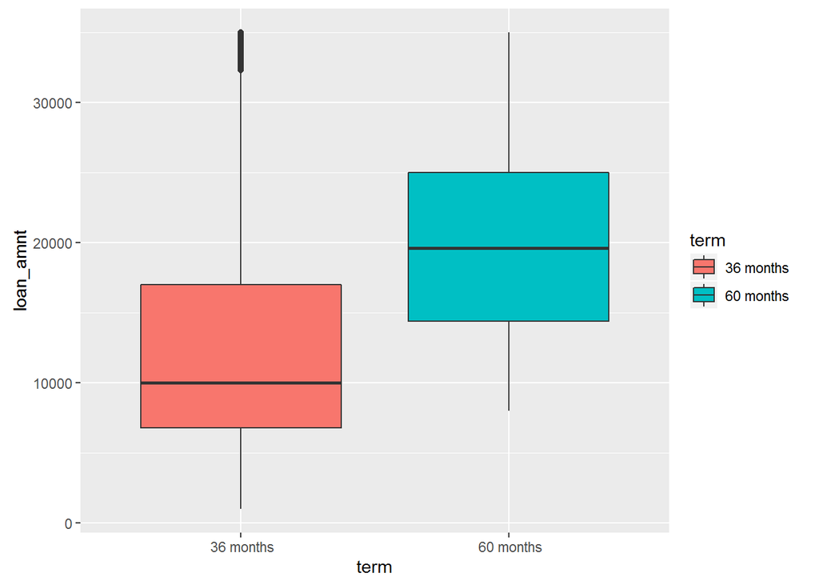

```r
ggplot(datab1,aes(x=term,y=loan_amnt,fill=term))+geom_boxplot()
```

```r
#Using One-Way ANOVA to test the significant relation between int_rate(continous) and term(categorical)
summary(aov(loan_amnt~term, datab1))
```

```
##                 Df    Sum Sq   Mean Sq F value Pr(>F)
## term             1 5.121e+12 5.121e+12   83531 <2e-16 ***
## Residuals   421093 2.582e+13 6.131e+07
## ---
## Signif. codes:  0 '***' 0.001 '**' 0.01 '*' 0.05 '.' 0.1 ' ' 1
```

The plot shows that the distribution of “loan_amnt” of 36-months “term” seems lower than 60-month and low p-value from the ANOVA test shows a significant relationship.

##### Set B2 (answer at least one question)

##### 1. The LC risk model has assigned records to different pricing tiers, indicated within the sub_grade variable. Using the sub_grade as the dependent variable, determine which other variables are most related/predictive and attempt to explain why.

There are various ways that can help us find the strong predictors of sub_grade, for example:

1. Run the logistic regression model and inspect the p-value of each Xi. A lower p-value means a significant relationship.(Remember to use VIF to check the colinear issues.)
2. After building the regression model, implement stepwise model selection, using backward, forward, stepwise to select the best set of predictors with lowest performance index, eg. AIC, BIC.
3. Inspect the correlation between Y and Xi to obtain the candidates of predictors which have significant relationships. But be aware that this is just a preliminary test as the true relation still would still consider the spurious correlation and collinearity in the further analysis.
4. Use the decision tree to build a classification model and inspect the node’s variable which brings a significant pruning impact.

In this case, first I will do the preliminary correlation testing with ANOVA and Chi-square:

```r
#Due to our target sub_grade as categorical variables, I will use ANOVA and Chi-square testing to inspect the relationship between predictors and our target, "sub_grade"
data2<-data[ , !(names(data) %in% c("sub_grade"))]
datatype<-sapply(data, class)
data_cate<-data2[sapply(data2,is.factor)] # factor type predictors
data_num<-data2[sapply(data2,is.numeric)] # numerica type predictors
cor_cate<-apply(data_cate,2, function(col) chisq.test(table(col, data$sub_grade))$p.value) # chisq-test
```

[output not shown]

```r
corall<-append(cor_cate,cor_num) # Get all p-value of correlations
```

[output not shown]

By using ANOVA and Chi-square testing, inspect the relation between predictors and “sub_grade”" so that we can rank the significance of relationship. Top ten candidates with significant relationships are(lowest p-value):

```r
names(sort.int(corall))[1:10]
```

```
##  [1] "term"                "int_rate"            "grade"
##  [4] "home_ownership"      "annual_inc"          "verification_status"
##  [7] "issue_d"             "loan_status"         "purpose"
## [10] "title"
```

Please note that this is only a rough test as we still have to consider the spurious correlation and collinearity of each predictos in a further analysis. I also strongly recommend discussing with domain experts and to do the graph analysis to make the final manual model selection more suitable for real world cases.

Now, I am going to run the logistic regression to build the predicted model and find the strong predictors:

```r
#Clean the data first

#Find the variable which has too many levels or missing data or one with only one level. In general, I will suggest trying to reduce the dimension by bining, but in this case, I will delete them.

dl<-sapply(data, function(x) nlevels(x))
data2=data[,-which(dl>100 | dl==1)]
dl<-sapply(data2, function(x) sum(is.na(x)))
data2<-data2[,-which(dl>20)]
data2<-na.omit(data2)
```

```r
data2<-data2[ , !(names(data2) %in% c("pymnt_plan","desc","initial_list_status","application_type","verification_status_joint","policy_code"))]

#In this case, due to the computing limit, I will only take 1% sample data to find the strong predictors.
set.seed(1)
spt<-sample(1:nrow(data2),nrow(data2)*0.01)
data3=data2[spt,]
tp<-sample(2,nrow(data3),replace = T, prob=c(0.7,0.3))
training<-data3[tp==1,x]
test<-data3[tp==2,x]
fit<-glm(sub_grade~.,training)
summary(fit)
```

```
##
## Call:
## glm(formula = sub_grade ~. , data = training)
##
## Deviance Residuals:
##      Min        1Q    Median        3Q       Max
## -2.82662   0.00001   0.00001   0.00002   2.25967
##
## Coefficients: (1 not defined because of singularities)
##                                      Estimate Std. Error z value Pr(>|z|)
## (Intercept)                         7.970e+00  3.795e+00   2.100 0.035736
## id                                  2.943e-09  4.717e-08   0.062 0.950258
## loan_amnt                           1.747e-03  6.930e-03   0.252 0.800981
## funded_amnt                                NA         NA      NA       NA
## funded_amnt_inv                    -1.675e-03  6.928e-03  -0.242 0.808912
## installment                        -3.391e-03  3.787e-03  -0.895 0.370612
## gradeB                              2.059e+01  1.534e+03   0.013 0.989292
## gradeC                              2.018e+01  1.467e+03   0.014 0.989028
## gradeD                              1.956e+01  2.100e+03   0.009 0.992569
## gradeE                              1.944e+01  2.632e+03   0.007 0.994108
## gradeF                              1.881e+01  5.290e+03   0.004 0.997164
## gradeG                              1.723e+01  1.104e+04   0.002 0.998755
## home_ownershipOWN                   6.686e-01  5.034e-01   1.328 0.184160
## home_ownershipRENT                  3.915e-01  3.842e-01   1.019 0.308198
## verification_statusSource Verified  2.549e-02  2.968e-01   0.086 0.931536
## verification_statusVerified         1.240e+00  4.903e-01   2.529 0.011445
## issue_dAug-15                       4.227e-01  1.068e+00   0.396 0.692261
## issue_dDec-15                      -1.036e+00  1.301e+00  -0.796 0.426188
## issue_dFeb-15                       2.228e-01  1.028e+00   0.217 0.828450
## issue_dJan-15                      -5.090e-01  7.946e-01  -0.641 0.521807
## issue_dJul-15                      -3.906e-01  8.961e-01  -0.436 0.662903
## issue_dJun-15                       2.119e-01  8.591e-01   0.247 0.805137
## issue_dMar-15                       2.127e-01  8.618e-01   0.247 0.805051
## issue_dMay-15                      -7.768e-01  7.881e-01  -0.986 0.324349
## issue_dNov-15                      -8.314e-01  1.246e+00  -0.667 0.504761
## issue_dOct-15                      -7.572e-01  1.131e+00  -0.669 0.503322
## issue_dSep-15                       1.887e-02  1.140e+00   0.017 0.986786
## dti                                 3.900e-02  2.237e-02   1.744 0.081214
## inq_last_6mths                      5.970e-01  3.037e-01   1.966 0.049323
## open_acc                           -9.053e-02  5.874e-02  -1.541 0.123277
```

[output cut: 72 more lines]

```
## num_tl_30dpd
## num_tl_op_past_12m
## pct_tl_nvr_dlq                     *
## tot_hi_cred_lim
## total_bal_ex_mort
## ---
## Signif. codes:  0 '***' 0.001 '**' 0.01 '*' 0.05 '.' 0.1 ' ' 1
##
## (Dispersion parameter for binomial family taken to be 1)
##
##     Null deviance: 872.55  on 2936  degrees of freedom
## Residual deviance: 396.08  on 2885  degrees of freedom
## AIC: 500.08
##
## Number of Fisher Scoring iterations: 21
```

We can find the strong predictors by checking p-value in the summary table. The one with an asterisk has a significant relationship with Y. I will recommend checking the VIF and run the stepwise model selection in future research to assure the power of predictors.